# Supervised Learning Capstone Project - Tree Methods Focus

# GOAL: Create a model to predict whether or not a customer will Churn .

```python
# Import the belwo to START THE PROJECT!
import numpy as np
import pandas as pd
import matplotlib.pyplot as plt

import seaborn as sns
```

```python
df = pd.read_csv('C:\\Users\\Ravi Nadageri\\Desktop\\Py_Practice _file\\ML_models\\Telco-Customer-Churn.csv')
```

```python
df.head()
```

|  | customerID | gender | SeniorCitizen | Partner | Dependents | tenure | PhoneService | MultipleLines | InternetService | OnlineSecurity | ... | DeviceProtection | TechSupport | StreamingTV | StreamingMovies | Contract | PaperlessBilling | PaymentMethod | MonthlyCharges | TotalCharges | Churn |
| --- | --- | --- | --- | --- | --- | --- | --- | --- | --- | --- | --- | --- | --- | --- | --- | --- | --- | --- | --- | --- | --- |
| 0 | 7590-VHVEG | Female | 0 | Yes | No | 1 | No | No phone service | DSL | No | ... | No | No | No | No | Month-to-month | Yes | Electronic check | 29.85 | 29.85 | No |
| 1 | 5575-GNVDE | Male | 0 | No | No | 34 | Yes | No | DSL | Yes | ... | Yes | No | No | No | One year | No | Mailed check | 56.95 | 1889.50 | No |
| 2 | 3668-QPYBK | Male | 0 | No | No | 2 | Yes | No | DSL | Yes | ... | No | No | No | No | Month-to-month | Yes | Mailed check | 53.85 | 108.15 | Yes |
| 3 | 7795-CFOCW | Male | 0 | No | No | 45 | No | No phone service | DSL | Yes | ... | Yes | Yes | No | No | One year | No | Bank transfer (automatic) | 42.30 | 1840.75 | No |
| 4 | 9237-HQITU | Female | 0 | No | No | 2 | Yes | No | Fiber optic | No | ... | No | No | No | No | Month-to-month | Yes | Electronic check | 70.70 | 151.65 | Yes |

5 rows × 21 columns

## Part 1: Quick Data Check

```python
df.info()
```

```
<class 'pandas.core.frame.DataFrame'>
RangeIndex: 7032 entries, 0 to 7031
Data columns (total 21 columns):
 #   Column            Non-Null Count  Dtype
---  ------            --------------  -----
 0   customerID        7032 non-null   object
 1   gender            7032 non-null   object
 2   SeniorCitizen     7032 non-null   int64
 3   Partner           7032 non-null   object
 4   Dependents        7032 non-null   object
 5   tenure            7032 non-null   int64
 6   PhoneService      7032 non-null   object
 7   MultipleLines     7032 non-null   object
 8   InternetService   7032 non-null   object
 9   OnlineSecurity    7032 non-null   object
 10  OnlineBackup      7032 non-null   object
 11  DeviceProtection  7032 non-null   object
 12  TechSupport       7032 non-null   object
 13  StreamingTV       7032 non-null   object
 14  StreamingMovies   7032 non-null   object
 15  Contract          7032 non-null   object
 16  PaperlessBilling  7032 non-null   object
 17  PaymentMethod     7032 non-null   object
 18  MonthlyCharges    7032 non-null   float64
 19  TotalCharges      7032 non-null   float64
 20  Churn             7032 non-null   object
dtypes: float64(2), int64(2), object(17)
memory usage: 1.1+ MB
```

**TASK: Get a quick statistical summary of the numeric columns with .describe() , you should notice that many columns are categorical, meaning you will eventually need to convert them to dummy variables.**

```python
df.describe()
```

|  | SeniorCitizen | tenure | MonthlyCharges | TotalCharges |
| --- | --- | --- | --- | --- |
| count | 7032.000000 | 7032.000000 | 7032.000000 | 7032.000000 |
| mean | 0.162400 | 32.421786 | 64.798208 | 2283.300441 |
| std | 0.368844 | 24.545260 | 30.085974 | 2266.771362 |
| min | 0.000000 | 1.000000 | 18.250000 | 18.800000 |
| 25% | 0.000000 | 9.000000 | 35.587500 | 401.450000 |
| 50% | 0.000000 | 29.000000 | 70.350000 | 1397.475000 |
| 75% | 0.000000 | 55.000000 | 89.862500 | 3794.737500 |
| max | 1.000000 | 72.000000 | 118.750000 | 8684.800000 |

# Part 2: Exploratory Data Analysis

## General Feature Exploration

**TASK: Confirm that there are no NaN cells by displaying NaN values per feature column.**

```python
df.isna().sum()
```

```
customerID          0
gender              0
SeniorCitizen       0
Partner             0
Dependents          0
tenure              0
PhoneService        0
MultipleLines       0
InternetService     0
OnlineSecurity      0
OnlineBackup        0
DeviceProtection    0
TechSupport         0
StreamingTV         0
StreamingMovies     0
Contract            0
PaperlessBilling    0
PaymentMethod       0
MonthlyCharges      0
TotalCharges        0
Churn               0
dtype: int64
```

**TASK:Display the balance of the class labels (Churn) with a Count Plot.**

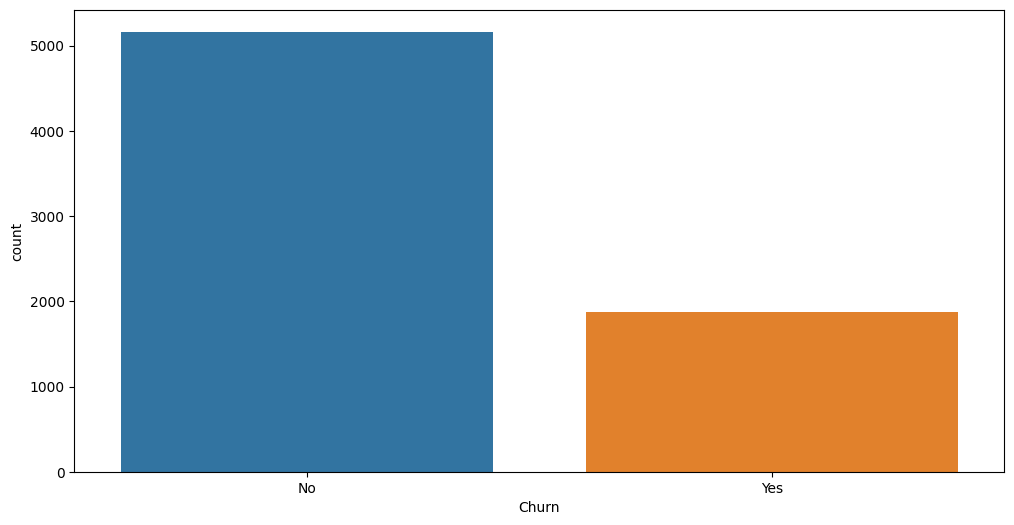

```python
plt.rcParams['figure.figsize'] = (12,6)
sns.countplot(data=df,x='Churn')
```

**TASK: Explore the distrbution of TotalCharges between Churn categories with a Box Plot or Violin Plot.**

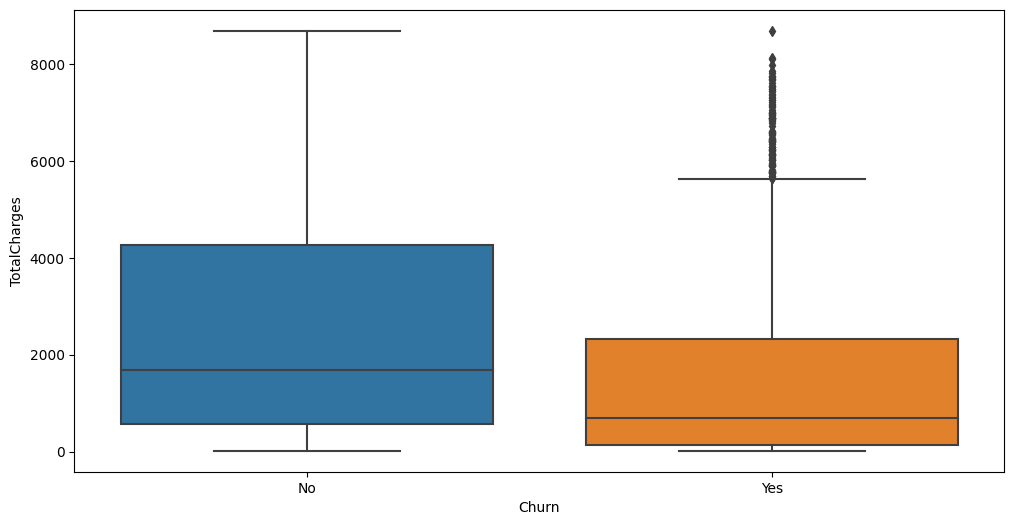

```python
sns.boxplot(data=df,x='Churn',y='TotalCharges')
```

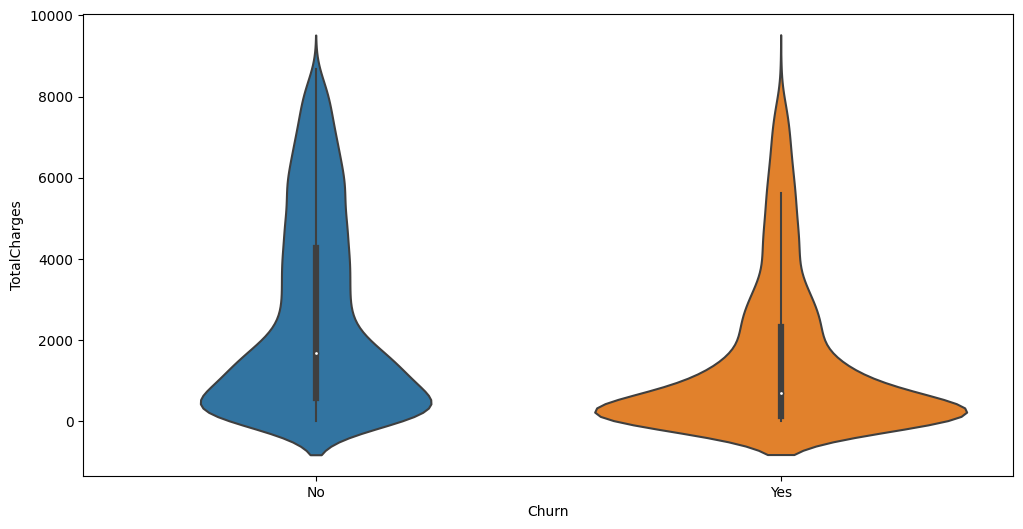

```python
sns.violinplot(data=df,x='Churn',y='TotalCharges')
```

**TASK: Create a boxplot showing the distribution of TotalCharges per Contract type, also add in a hue coloring based on the Churn class.**

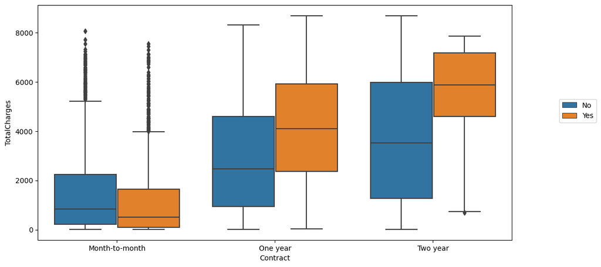

```python
sns.boxplot(x='Contract',y='TotalCharges',data=df,hue='Churn')
plt.legend(loc=(1.1,0.5))
```

**TASK: Create a bar plot showing the correlation of the following features to the class label. Keep in mind, for the categorical features, you will need to convert them into dummy variables first, as you can only calculate correlation for numeric features.**

```
['gender', 'SeniorCitizen', 'Partner', 'Dependents','PhoneService', 'MultipleLines',
 'OnlineSecurity', 'OnlineBackup', 'DeviceProtection', 'TechSupport', 'InternetService',
   'StreamingTV', 'StreamingMovies', 'Contract', 'PaperlessBilling', 'PaymentMethod']
```

***Note, we specifically listed only the features above, you should not check the correlation for every feature, as some features have too many unique instances for such an analysis, such as customerID***

```python
df_dummy = pd.get_dummies(df[['gender', 'SeniorCitizen', 'Partner', 'Dependents','PhoneService', 'MultipleLines',
     'OnlineSecurity', 'OnlineBackup', 'DeviceProtection', 'TechSupport', 'InternetService',
       'StreamingTV', 'StreamingMovies', 'Contract', 'PaperlessBilling', 'PaymentMethod','Churn']])
```

```python
df_dummy.head()
```

|  | SeniorCitizen | gender_Female | gender_Male | Partner_No | Partner_Yes | Dependents_No | Dependents_Yes | PhoneService_No | PhoneService_Yes | MultipleLines_No | ... | Contract_One year | Contract_Two year | PaperlessBilling_No | PaperlessBilling_Yes | PaymentMethod_Bank transfer (automatic) | PaymentMethod_Credit card (automatic) | PaymentMethod_Electronic check | PaymentMethod_Mailed check | Churn_No | Churn_Yes |
| --- | --- | --- | --- | --- | --- | --- | --- | --- | --- | --- | --- | --- | --- | --- | --- | --- | --- | --- | --- | --- | --- |
| 0 | 0 | 1 | 0 | 0 | 1 | 1 | 0 | 1 | 0 | 0 | ... | 0 | 0 | 0 | 1 | 0 | 0 | 1 | 0 | 1 | 0 |
| 1 | 0 | 0 | 1 | 1 | 0 | 1 | 0 | 0 | 1 | 1 | ... | 1 | 0 | 1 | 0 | 0 | 0 | 0 | 1 | 1 | 0 |
| 2 | 0 | 0 | 1 | 1 | 0 | 1 | 0 | 0 | 1 | 1 | ... | 0 | 0 | 0 | 1 | 0 | 0 | 0 | 1 | 0 | 1 |
| 3 | 0 | 0 | 1 | 1 | 0 | 1 | 0 | 1 | 0 | 0 | ... | 1 | 0 | 1 | 0 | 1 | 0 | 0 | 0 | 1 | 0 |
| 4 | 0 | 1 | 0 | 1 | 0 | 1 | 0 | 0 | 1 | 1 | ... | 0 | 0 | 0 | 1 | 0 | 0 | 1 | 0 | 0 | 1 |

5 rows × 44 columns

```python
df_dummy.corr()
```

|  | SeniorCitizen | gender_Female | gender_Male | Partner_No | Partner_Yes | Dependents_No | Dependents_Yes | PhoneService_No | PhoneService_Yes | MultipleLines_No | ... | Contract_One year | Contract_Two year | PaperlessBilling_No | PaperlessBilling_Yes | PaymentMethod_Bank transfer (automatic) | PaymentMethod_Credit card (automatic) | PaymentMethod_Electronic check | PaymentMethod_Mailed check | Churn_No | Churn_Yes |
| --- | --- | --- | --- | --- | --- | --- | --- | --- | --- | --- | --- | --- | --- | --- | --- | --- | --- | --- | --- | --- | --- |
| SeniorCitizen | 1.000000 | 0.001819 | -0.001819 | -0.016957 | 0.016957 | 0.210550 | -0.210550 | -0.008392 | 0.008392 | -0.136377 | ... | -0.046491 | -0.116205 | -0.156258 | 0.156258 | -0.016235 | -0.024359 | 0.171322 | -0.152987 | -0.150541 | 0.150541 |
| gender_Female | 0.001819 | 1.000000 | -1.000000 | -0.001379 | 0.001379 | 0.010349 | -0.010349 | -0.007515 | 0.007515 | -0.004335 | ... | -0.007755 | 0.003603 | -0.011902 | 0.011902 | 0.015973 | -0.001632 | -0.000844 | -0.013199 | -0.008545 | 0.008545 |
| gender_Male | -0.001819 | -1.000000 | 1.000000 | 0.001379 | -0.001379 | -0.010349 | 0.010349 | 0.007515 | -0.007515 | 0.004335 | ... | 0.007755 | -0.003603 | 0.011902 | -0.011902 | -0.015973 | 0.001632 | 0.000844 | 0.013199 | 0.008545 | -0.008545 |
| Partner_No | -0.016957 | -0.001379 | 0.001379 | 1.000000 | -1.000000 | 0.452269 | -0.452269 | 0.018397 | -0.018397 | 0.130028 | ... | -0.083067 | -0.247334 | -0.013957 | 0.013957 | -0.111406 | -0.082327 | 0.083207 | 0.096948 | -0.149982 | 0.149982 |
| Partner_Yes | 0.016957 | 0.001379 | -0.001379 | -1.000000 | 1.000000 | -0.452269 | 0.452269 | -0.018397 | 0.018397 | -0.130028 | ... | 0.083067 | 0.247334 | 0.013957 | -0.013957 | 0.111406 | 0.082327 | -0.083207 | -0.096948 | 0.149982 | -0.149982 |
| Dependents_No | 0.210550 | 0.010349 | -0.010349 | 0.452269 | -0.452269 | 1.000000 | -1.000000 | -0.001078 | 0.001078 | -0.023388 | ... | -0.069222 | -0.201699 | -0.110131 | 0.110131 | -0.052369 | -0.061134 | 0.149274 | -0.056448 | -0.163128 | 0.163128 |
| Dependents_Yes | -0.210550 | -0.010349 | 0.010349 | -0.452269 | 0.452269 | -1.000000 | 1.000000 | 0.001078 | -0.001078 | 0.023388 | ... | 0.069222 | 0.201699 | 0.110131 | -0.110131 | 0.052369 | 0.061134 | -0.149274 | 0.056448 | 0.163128 | -0.163128 |
| PhoneService_No | -0.008392 | -0.007515 | 0.007515 | 0.018397 | -0.018397 | -0.001078 | 0.001078 | 1.000000 | -1.000000 | -0.315218 | ... | 0.003142 | -0.004442 | 0.016696 | -0.016696 | -0.008271 | 0.006916 | -0.002747 | 0.004463 | 0.011691 | -0.011691 |
| PhoneService_Yes | 0.008392 | 0.007515 | -0.007515 | -0.018397 | 0.018397 | 0.001078 | -0.001078 | -1.000000 | 1.000000 | 0.315218 | ... | -0.003142 | 0.004442 | -0.016696 | 0.016696 | 0.008271 | -0.006916 | 0.002747 | -0.004463 | -0.011691 | 0.011691 |
| MultipleLines_No | -0.136377 | -0.004335 | 0.004335 | 0.130028 | -0.130028 | -0.023388 | 0.023388 | -0.315218 | 0.315218 | 1.000000 | ... | 0.001694 | -0.102756 | 0.151974 | -0.151974 | -0.069663 | -0.063712 | -0.080990 | 0.222395 | 0.032654 | -0.032654 |
| MultipleLines_No phone service | -0.008392 | -0.007515 | 0.007515 | 0.018397 | -0.018397 | -0.001078 | 0.001078 | 1.000000 | -1.000000 | -0.315218 | ... | 0.003142 | -0.004442 | 0.016696 | -0.016696 | -0.008271 | 0.006916 | -0.002747 | 0.004463 | 0.011691 | -0.011691 |
| MultipleLines_Yes | 0.142996 | 0.008883 | -0.008883 | -0.142561 | 0.142561 | 0.024307 | -0.024307 | -0.279530 | 0.279530 | -0.823076 | ... | -0.003594 | 0.106618 | -0.163746 | 0.163746 | 0.075429 | 0.060319 | 0.083583 | -0.227672 | -0.040033 | 0.040033 |
| OnlineSecurity_No | 0.185145 | -0.010859 | 0.010859 | 0.129394 | -0.129394 | 0.186979 | -0.186979 | 0.058546 | -0.058546 | -0.118032 | ... | -0.122360 | -0.352447 | -0.267592 | 0.267592 | -0.084436 | -0.105963 | 0.335854 | -0.190919 | -0.342235 | 0.342235 |
| OnlineSecurity_No internet service | -0.182519 | -0.004745 | 0.004745 | 0.000286 | -0.000286 | -0.138383 | 0.138383 | -0.171817 | 0.171817 | 0.309984 | ... | 0.038061 | 0.217542 | 0.320592 | -0.320592 | -0.001094 | 0.001870 | -0.284608 | 0.319694 | 0.227578 | -0.227578 |
| OnlineSecurity_Yes | -0.038576 | 0.016328 | -0.016328 | -0.143346 | 0.143346 | -0.080786 | 0.080786 | 0.091676 | -0.091676 | -0.151678 | ... | 0.100658 | 0.191698 | 0.004051 | -0.004051 | 0.094366 | 0.115473 | -0.112295 | -0.079918 | 0.171270 | -0.171270 |
| OnlineBackup_No | 0.087539 | -0.008605 | 0.008605 | 0.135626 | -0.135626 | 0.137421 | -0.137421 | 0.092579 | -0.092579 | -0.036126 | ... | -0.112133 | -0.287128 | -0.144218 | 0.144218 | -0.082365 | -0.088189 | 0.236414 | -0.098438 | -0.267595 | 0.267595 |
| OnlineBackup_No internet service | -0.182519 | -0.004745 | 0.004745 | 0.000286 | -0.000286 | -0.138383 | 0.138383 | -0.171817 | 0.171817 | 0.309984 | ... | 0.038061 | 0.217542 | 0.320592 | -0.320592 | -0.001094 | 0.001870 | -0.284608 | 0.319694 | 0.227578 | -0.227578 |
| OnlineBackup_Yes | 0.066663 | 0.013093 | -0.013093 | -0.141849 | 0.141849 | -0.023639 | 0.023639 | 0.052133 | -0.052133 | -0.230724 | ... | 0.084113 | 0.111391 | -0.127056 | 0.127056 | 0.086942 | 0.090455 | -0.000364 | -0.174075 | 0.082307 | -0.082307 |
| DeviceProtection_No | 0.094403 | 0.003163 | -0.003163 | 0.146702 | -0.146702 | 0.128053 | -0.128053 | 0.075421 | -0.075421 | -0.026582 | ... | -0.130038 | -0.338520 | -0.166253 | 0.166253 | -0.078561 | -0.108008 | 0.239173 | -0.085850 | -0.252056 | 0.252056 |
| DeviceProtection_No internet service | -0.182519 | -0.004745 | 0.004745 | 0.000286 | -0.000286 | -0.138383 | 0.138383 | -0.171817 | 0.171817 | 0.309984 | ... | 0.038061 | 0.217542 | 0.320592 | -0.320592 | -0.001094 | 0.001870 | -0.284608 | 0.319694 | 0.227578 | -0.227578 |
| DeviceProtection_Yes | 0.059514 | 0.000807 | -0.000807 | -0.153556 | 0.153556 | -0.013900 | 0.013900 | 0.070076 | -0.070076 | -0.240847 | ... | 0.102911 | 0.165248 | -0.104079 | 0.104079 | 0.083047 | 0.111252 | -0.003308 | -0.187325 | 0.066193 | -0.066193 |
| TechSupport_No | 0.205254 | -0.003815 | 0.003815 | 0.108875 | -0.108875 | 0.171164 | -0.171164 | 0.055102 | -0.055102 | -0.114036 | ... | -0.118709 | -0.397788 | -0.229875 | 0.229875 | -0.090296 | -0.107761 | 0.338529 | -0.186388 | -0.336877 | 0.336877 |
| TechSupport_No internet service | -0.182519 | -0.004745 | 0.004745 | 0.000286 | -0.000286 | -0.138383 | 0.138383 | -0.171817 | 0.171817 | 0.309984 | ... | 0.038061 | 0.217542 | 0.320592 | -0.320592 | -0.001094 | 0.001870 | -0.284608 | 0.319694 | 0.227578 | -0.227578 |
| TechSupport_Yes | -0.060577 | 0.008507 | -0.008507 | -0.120206 | 0.120206 | -0.063053 | 0.063053 | 0.095138 | -0.095138 | -0.155534 | ... | 0.096258 | 0.240924 | -0.037536 | 0.037536 | 0.100472 | 0.117024 | -0.114807 | -0.084631 | 0.164716 | -0.164716 |
| InternetService_DSL | -0.108276 | -0.007584 | 0.007584 | 0.001043 | -0.001043 | -0.051593 | 0.051593 | 0.452255 | -0.452255 | -0.069515 | ... | 0.047300 | 0.030924 | 0.063390 | -0.063390 | 0.024760 | 0.051222 | -0.104293 | 0.042754 | 0.124141 | -0.124141 |
| InternetService_Fiber optic | 0.254923 | 0.011189 | -0.011189 | -0.001235 | 0.001235 | 0.164101 | -0.164101 | -0.290183 | 0.290183 | -0.190531 | ... | -0.076809 | -0.209965 | -0.326470 | 0.326470 | -0.022779 | -0.050552 | 0.335763 | -0.305984 | -0.307463 | 0.307463 |
| InternetService_No | -0.182519 | -0.004745 | 0.004745 | 0.000286 | -0.000286 | -0.138383 | 0.138383 | -0.171817 | 0.171817 | 0.309984 | ... | 0.038061 | 0.217542 | 0.320592 | -0.320592 | -0.001094 | 0.001870 | -0.284608 | 0.319694 | 0.227578 | -0.227578 |
| StreamingTV_No | 0.048664 | -0.003088 | 0.003088 | 0.123394 | -0.123394 | 0.099912 | -0.099912 | 0.123159 | -0.123159 | 0.005131 | ... | -0.093495 | -0.254456 | -0.046715 | 0.046715 | -0.044887 | -0.041309 | 0.095426 | -0.022650 | -0.128435 | 0.128435 |
| StreamingTV_No internet service | -0.182519 | -0.004745 | 0.004745 | 0.000286 | -0.000286 | -0.138383 | 0.138383 | -0.171817 | 0.171817 | 0.309984 | ... | 0.038061 | 0.217542 | 0.320592 | -0.320592 | -0.001094 | 0.001870 | -0.284608 | 0.319694 | 0.227578 | -0.227578 |
| StreamingTV_Yes | 0.105445 | 0.007124 | -0.007124 | -0.124483 | 0.124483 | 0.016499 | -0.016499 | 0.021383 | -0.021383 | -0.267466 | ... | 0.061930 | 0.072124 | -0.224241 | 0.224241 | 0.046121 | 0.040010 | 0.144747 | -0.247712 | -0.063254 | 0.063254 |
| StreamingMovies_No | 0.034196 | -0.006078 | 0.006078 | 0.117488 | -0.117488 | 0.078245 | -0.078245 | 0.111273 | -0.111273 | 0.014149 | ... | -0.096613 | -0.258495 | -0.058987 | 0.058987 | -0.047677 | -0.049817 | 0.102617 | -0.019648 | -0.130920 | 0.130920 |
| StreamingMovies_No internet service | -0.182519 | -0.004745 | 0.004745 | 0.000286 | -0.000286 | -0.138383 | 0.138383 | -0.171817 | 0.171817 | 0.309984 | ... | 0.038061 | 0.217542 | 0.320592 | -0.320592 | -0.001094 | 0.001870 | -0.284608 | 0.319694 | 0.227578 | -0.227578 |
| StreamingMovies_Yes | 0.119842 | 0.010105 | -0.010105 | -0.118108 | 0.118108 | 0.038375 | -0.038375 | 0.033477 | -0.033477 | -0.275995 | ... | 0.064780 | 0.075603 | -0.211583 | 0.211583 | 0.048755 | 0.048398 | 0.137420 | -0.250290 | -0.060860 | 0.060860 |
| Contract_Month-to-month | 0.137752 | 0.003251 | -0.003251 | 0.280202 | -0.280202 | 0.229715 | -0.229715 | 0.001243 | -0.001243 | 0.086798 | ... | -0.570053 | -0.621933 | -0.168296 | 0.168296 | -0.180159 | -0.204960 | 0.330879 | 0.006209 | -0.404565 | 0.404565 |
| Contract_One year | -0.046491 | -0.007755 | 0.007755 | -0.083067 | 0.083067 | -0.069222 | 0.069222 | 0.003142 | -0.003142 | 0.001694 | ... | 1.000000 | -0.288843 | 0.052278 | -0.052278 | 0.057629 | 0.067590 | -0.109546 | 0.000197 | 0.178225 | -0.178225 |
| Contract_Two year | -0.116205 | 0.003603 | -0.003603 | -0.247334 | 0.247334 | -0.201699 | 0.201699 | -0.004442 | 0.004442 | -0.102756 | ... | -0.288843 | 1.000000 | 0.146281 | -0.146281 | 0.155004 | 0.174410 | -0.281147 | -0.007423 | 0.301552 | -0.301552 |
| PaperlessBilling_No | -0.156258 | -0.011902 | 0.011902 | -0.013957 | 0.013957 | -0.110131 | 0.110131 | 0.016696 | -0.016696 | 0.151974 | ... | 0.052278 | 0.146281 | 1.000000 | -1.000000 | 0.017469 | 0.013726 | -0.208427 | 0.203981 | 0.191454 | -0.191454 |
| PaperlessBilling_Yes | 0.156258 | 0.011902 | -0.011902 | 0.013957 | -0.013957 | 0.110131 | -0.110131 | -0.016696 | 0.016696 | -0.151974 | ... | -0.052278 | -0.146281 | -1.000000 | 1.000000 | -0.017469 | -0.013726 | 0.208427 | -0.203981 | -0.191454 | 0.191454 |
| PaymentMethod_Bank transfer (automatic) | -0.016235 | 0.015973 | -0.015973 | -0.111406 | 0.111406 | -0.052369 | 0.052369 | -0.008271 | 0.008271 | -0.069663 | ... | 0.057629 | 0.155004 | 0.017469 | -0.017469 | 1.000000 | -0.278423 | -0.377270 | -0.288097 | 0.118136 | -0.118136 |
| PaymentMethod_Credit card (automatic) | -0.024359 | -0.001632 | 0.001632 | -0.082327 | 0.082327 | -0.061134 | 0.061134 | 0.006916 | -0.006916 | -0.063712 | ... | 0.067590 | 0.174410 | 0.013726 | -0.013726 | -0.278423 | 1.000000 | -0.373978 | -0.285583 | 0.134687 | -0.134687 |
| PaymentMethod_Electronic check | 0.171322 | -0.000844 | 0.000844 | 0.083207 | -0.083207 | 0.149274 | -0.149274 | -0.002747 | 0.002747 | -0.080990 | ... | -0.109546 | -0.281147 | -0.208427 | 0.208427 | -0.377270 | -0.373978 | 1.000000 | -0.386971 | -0.301455 | 0.301455 |
| PaymentMethod_Mailed check | -0.152987 | -0.013199 | 0.013199 | 0.096948 | -0.096948 | -0.056448 | 0.056448 | 0.004463 | -0.004463 | 0.222395 | ... | 0.000197 | -0.007423 | 0.203981 | -0.203981 | -0.288097 | -0.285583 | -0.386971 | 1.000000 | 0.090773 | -0.090773 |
| Churn_No | -0.150541 | -0.008545 | 0.008545 | -0.149982 | 0.149982 | -0.163128 | 0.163128 | 0.011691 | -0.011691 | 0.032654 | ... | 0.178225 | 0.301552 | 0.191454 | -0.191454 | 0.118136 | 0.134687 | -0.301455 | 0.090773 | 1.000000 | -1.000000 |
| Churn_Yes | 0.150541 | 0.008545 | -0.008545 | 0.149982 | -0.149982 | 0.163128 | -0.163128 | -0.011691 | 0.011691 | -0.032654 | ... | -0.178225 | -0.301552 | -0.191454 | 0.191454 | -0.118136 | -0.134687 | 0.301455 | -0.090773 | -1.000000 | 1.000000 |

44 rows × 44 columns

```python
df_corr = df_dummy.corr()['Churn_Yes'].sort_values().iloc[1:-1] #it will ommit the first and last one
```

```python
df_corr
```

```
Contract_Two year                         -0.301552
DeviceProtection_No internet service      -0.227578
StreamingMovies_No internet service       -0.227578
StreamingTV_No internet service           -0.227578
InternetService_No                        -0.227578
TechSupport_No internet service           -0.227578
OnlineBackup_No internet service          -0.227578
OnlineSecurity_No internet service        -0.227578
PaperlessBilling_No                       -0.191454
Contract_One year                         -0.178225
OnlineSecurity_Yes                        -0.171270
TechSupport_Yes                           -0.164716
Dependents_Yes                            -0.163128
Partner_Yes                               -0.149982
PaymentMethod_Credit card (automatic)     -0.134687
InternetService_DSL                       -0.124141
PaymentMethod_Bank transfer (automatic)   -0.118136
PaymentMethod_Mailed check                -0.090773
OnlineBackup_Yes                          -0.082307
DeviceProtection_Yes                      -0.066193
MultipleLines_No                          -0.032654
MultipleLines_No phone service            -0.011691
PhoneService_No                           -0.011691
gender_Male                               -0.008545
gender_Female                              0.008545
PhoneService_Yes                           0.011691
MultipleLines_Yes                          0.040033
StreamingMovies_Yes                        0.060860
StreamingTV_Yes                            0.063254
StreamingTV_No                             0.128435
StreamingMovies_No                         0.130920
Partner_No                                 0.149982
SeniorCitizen                              0.150541
Dependents_No                              0.163128
PaperlessBilling_Yes                       0.191454
DeviceProtection_No                        0.252056
OnlineBackup_No                            0.267595
PaymentMethod_Electronic check             0.301455
InternetService_Fiber optic                0.307463
TechSupport_No                             0.336877
OnlineSecurity_No                          0.342235
Contract_Month-to-month                    0.404565
Name: Churn_Yes, dtype: float64
```

```
(array([ 0,  1,  2,  3,  4,  5,  6,  7,  8,  9, 10, 11, 12, 13, 14, 15, 16,
        17, 18, 19, 20, 21, 22, 23, 24, 25, 26, 27, 28, 29, 30, 31, 32, 33,
        34, 35, 36, 37, 38, 39, 40, 41]),
 [Text(0, 0, 'Contract_Two year'),
```

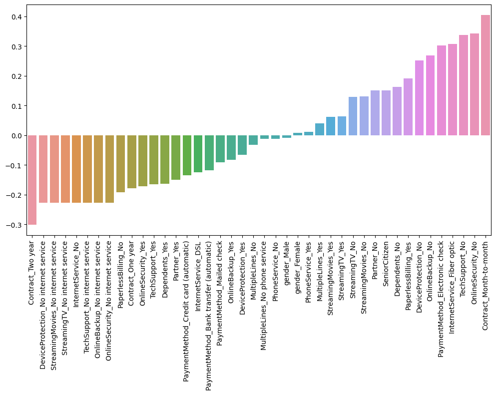

```python
sns.barplot(x=df_corr.index,y=df_corr.values)
plt.xticks(rotation = 90)
```

[figure not shown]

# Part 3: Churn Analysis

**This section focuses on segementing customers based on their tenure, creating "cohorts", allowing us to examine differences between customer cohort segments.**

**TASK: What are the 3 contract types available?**

```python
df.Contract.unique()
```

```
array(['Month-to-month', 'One year', 'Two year'], dtype=object)
```

**TASK: Create a histogram displaying the distribution of 'tenure' column, which is the amount of months a customer was or has been on a customer.**

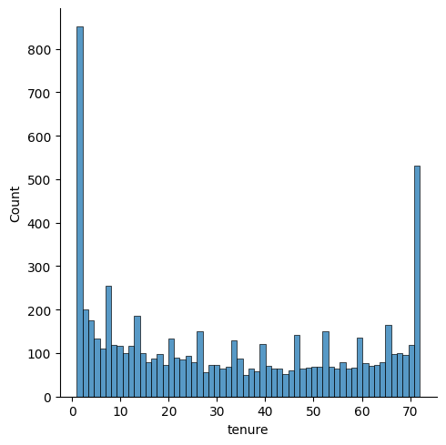

```python
plt.rcParams['figure.figsize'] = [10,6]
fig = plt.figure()
plt.Figure(figsize=(2,6))

sns.displot(data=df,x='tenure',bins=60)
```

**TASK: Now use the seaborn documentation as a guide to create histograms separated by two additional features, Churn and Contract.**

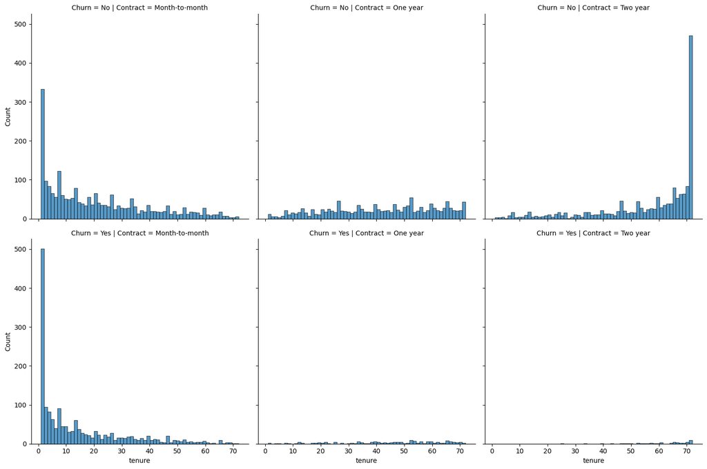

```python
sns.displot(data=df,x='tenure',bins=60,col='Contract',row="Churn")
```

**TASK: Display a scatter plot of Total Charges versus Monthly Charges, and color hue by Churn.**

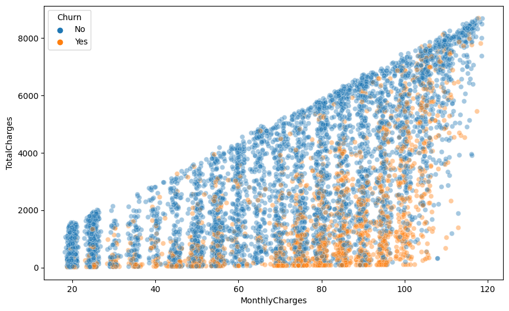

```python
sns.scatterplot(data=df,
                x='MonthlyCharges',
                y='TotalCharges',
                hue='Churn',alpha=0.4)
```

### Creating Cohorts based on Tenure

**Let's begin by treating each unique tenure length, 1 month, 2 month, 3 month...N months as its own cohort.**

**TASK: Treating each unique tenure group as a cohort, calculate the Churn rate (percentage that had Yes Churn) per cohort. For example, the cohort that has had a tenure of 1 month should have a Churn rate of 61.99%. You should have cohorts 1-72 months with a general trend of the longer the tenure of the cohort, the less of a churn rate. This makes sense as you are less likely to stop service the longer you've had it.**

```python
df.groupby(['Churn','tenure']).count()
```

| Churn | tenure | customerID | gender | SeniorCitizen | Partner | Dependents | PhoneService | MultipleLines | InternetService | OnlineSecurity | OnlineBackup | DeviceProtection | TechSupport | StreamingTV | StreamingMovies | Contract | PaperlessBilling | PaymentMethod | MonthlyCharges | TotalCharges |
| --- | --- | --- | --- | --- | --- | --- | --- | --- | --- | --- | --- | --- | --- | --- | --- | --- | --- | --- | --- | --- |
| No | 1 | 233 | 233 | 233 | 233 | 233 | 233 | 233 | 233 | 233 | 233 | 233 | 233 | 233 | 233 | 233 | 233 | 233 | 233 | 233 |
|  | 2 | 115 | 115 | 115 | 115 | 115 | 115 | 115 | 115 | 115 | 115 | 115 | 115 | 115 | 115 | 115 | 115 | 115 | 115 | 115 |
|  | 3 | 106 | 106 | 106 | 106 | 106 | 106 | 106 | 106 | 106 | 106 | 106 | 106 | 106 | 106 | 106 | 106 | 106 | 106 | 106 |
|  | 4 | 93 | 93 | 93 | 93 | 93 | 93 | 93 | 93 | 93 | 93 | 93 | 93 | 93 | 93 | 93 | 93 | 93 | 93 | 93 |
|  | 5 | 69 | 69 | 69 | 69 | 69 | 69 | 69 | 69 | 69 | 69 | 69 | 69 | 69 | 69 | 69 | 69 | 69 | 69 | 69 |
| ... | ... | ... | ... | ... | ... | ... | ... | ... | ... | ... | ... | ... | ... | ... | ... | ... | ... | ... | ... | ... |
| Yes | 68 | 9 | 9 | 9 | 9 | 9 | 9 | 9 | 9 | 9 | 9 | 9 | 9 | 9 | 9 | 9 | 9 | 9 | 9 | 9 |
|  | 69 | 8 | 8 | 8 | 8 | 8 | 8 | 8 | 8 | 8 | 8 | 8 | 8 | 8 | 8 | 8 | 8 | 8 | 8 | 8 |
|  | 70 | 11 | 11 | 11 | 11 | 11 | 11 | 11 | 11 | 11 | 11 | 11 | 11 | 11 | 11 | 11 | 11 | 11 | 11 | 11 |
|  | 71 | 6 | 6 | 6 | 6 | 6 | 6 | 6 | 6 | 6 | 6 | 6 | 6 | 6 | 6 | 6 | 6 | 6 | 6 | 6 |
|  | 72 | 6 | 6 | 6 | 6 | 6 | 6 | 6 | 6 | 6 | 6 | 6 | 6 | 6 | 6 | 6 | 6 | 6 | 6 | 6 |

144 rows × 19 columns

```python
yes_churn = df.groupby(['Churn','tenure']).count().T['Yes']
no_churn = df.groupby(['Churn','tenure']).count().T['No']
yes_churn
```

| tenure | 1 | 2 | 3 | 4 | 5 | 6 | 7 | 8 | 9 | 10 | ... | 63 | 64 | 65 | 66 | 67 | 68 | 69 | 70 | 71 | 72 |
| --- | --- | --- | --- | --- | --- | --- | --- | --- | --- | --- | --- | --- | --- | --- | --- | --- | --- | --- | --- | --- | --- |
| customerID | 380 | 123 | 94 | 83 | 64 | 40 | 51 | 42 | 46 | 45 | ... | 4 | 4 | 9 | 13 | 10 | 9 | 8 | 11 | 6 | 6 |
| gender | 380 | 123 | 94 | 83 | 64 | 40 | 51 | 42 | 46 | 45 | ... | 4 | 4 | 9 | 13 | 10 | 9 | 8 | 11 | 6 | 6 |
| SeniorCitizen | 380 | 123 | 94 | 83 | 64 | 40 | 51 | 42 | 46 | 45 | ... | 4 | 4 | 9 | 13 | 10 | 9 | 8 | 11 | 6 | 6 |
| Partner | 380 | 123 | 94 | 83 | 64 | 40 | 51 | 42 | 46 | 45 | ... | 4 | 4 | 9 | 13 | 10 | 9 | 8 | 11 | 6 | 6 |
| Dependents | 380 | 123 | 94 | 83 | 64 | 40 | 51 | 42 | 46 | 45 | ... | 4 | 4 | 9 | 13 | 10 | 9 | 8 | 11 | 6 | 6 |
| PhoneService | 380 | 123 | 94 | 83 | 64 | 40 | 51 | 42 | 46 | 45 | ... | 4 | 4 | 9 | 13 | 10 | 9 | 8 | 11 | 6 | 6 |
| MultipleLines | 380 | 123 | 94 | 83 | 64 | 40 | 51 | 42 | 46 | 45 | ... | 4 | 4 | 9 | 13 | 10 | 9 | 8 | 11 | 6 | 6 |
| InternetService | 380 | 123 | 94 | 83 | 64 | 40 | 51 | 42 | 46 | 45 | ... | 4 | 4 | 9 | 13 | 10 | 9 | 8 | 11 | 6 | 6 |
| OnlineSecurity | 380 | 123 | 94 | 83 | 64 | 40 | 51 | 42 | 46 | 45 | ... | 4 | 4 | 9 | 13 | 10 | 9 | 8 | 11 | 6 | 6 |
| OnlineBackup | 380 | 123 | 94 | 83 | 64 | 40 | 51 | 42 | 46 | 45 | ... | 4 | 4 | 9 | 13 | 10 | 9 | 8 | 11 | 6 | 6 |
| DeviceProtection | 380 | 123 | 94 | 83 | 64 | 40 | 51 | 42 | 46 | 45 | ... | 4 | 4 | 9 | 13 | 10 | 9 | 8 | 11 | 6 | 6 |
| TechSupport | 380 | 123 | 94 | 83 | 64 | 40 | 51 | 42 | 46 | 45 | ... | 4 | 4 | 9 | 13 | 10 | 9 | 8 | 11 | 6 | 6 |
| StreamingTV | 380 | 123 | 94 | 83 | 64 | 40 | 51 | 42 | 46 | 45 | ... | 4 | 4 | 9 | 13 | 10 | 9 | 8 | 11 | 6 | 6 |
| StreamingMovies | 380 | 123 | 94 | 83 | 64 | 40 | 51 | 42 | 46 | 45 | ... | 4 | 4 | 9 | 13 | 10 | 9 | 8 | 11 | 6 | 6 |
| Contract | 380 | 123 | 94 | 83 | 64 | 40 | 51 | 42 | 46 | 45 | ... | 4 | 4 | 9 | 13 | 10 | 9 | 8 | 11 | 6 | 6 |
| PaperlessBilling | 380 | 123 | 94 | 83 | 64 | 40 | 51 | 42 | 46 | 45 | ... | 4 | 4 | 9 | 13 | 10 | 9 | 8 | 11 | 6 | 6 |
| PaymentMethod | 380 | 123 | 94 | 83 | 64 | 40 | 51 | 42 | 46 | 45 | ... | 4 | 4 | 9 | 13 | 10 | 9 | 8 | 11 | 6 | 6 |
| MonthlyCharges | 380 | 123 | 94 | 83 | 64 | 40 | 51 | 42 | 46 | 45 | ... | 4 | 4 | 9 | 13 | 10 | 9 | 8 | 11 | 6 | 6 |
| TotalCharges | 380 | 123 | 94 | 83 | 64 | 40 | 51 | 42 | 46 | 45 | ... | 4 | 4 | 9 | 13 | 10 | 9 | 8 | 11 | 6 | 6 |

19 rows × 72 columns

```python
churn_rate = 100* yes_churn / (yes_churn + no_churn)
```

```python
churn_rate.T
```

| tenure | customerID | gender | SeniorCitizen | Partner | Dependents | PhoneService | MultipleLines | InternetService | OnlineSecurity | OnlineBackup | DeviceProtection | TechSupport | StreamingTV | StreamingMovies | Contract | PaperlessBilling | PaymentMethod | MonthlyCharges | TotalCharges |
| --- | --- | --- | --- | --- | --- | --- | --- | --- | --- | --- | --- | --- | --- | --- | --- | --- | --- | --- | --- |
| 1 | 61.990212 | 61.990212 | 61.990212 | 61.990212 | 61.990212 | 61.990212 | 61.990212 | 61.990212 | 61.990212 | 61.990212 | 61.990212 | 61.990212 | 61.990212 | 61.990212 | 61.990212 | 61.990212 | 61.990212 | 61.990212 | 61.990212 |
| 2 | 51.680672 | 51.680672 | 51.680672 | 51.680672 | 51.680672 | 51.680672 | 51.680672 | 51.680672 | 51.680672 | 51.680672 | 51.680672 | 51.680672 | 51.680672 | 51.680672 | 51.680672 | 51.680672 | 51.680672 | 51.680672 | 51.680672 |
| 3 | 47.000000 | 47.000000 | 47.000000 | 47.000000 | 47.000000 | 47.000000 | 47.000000 | 47.000000 | 47.000000 | 47.000000 | 47.000000 | 47.000000 | 47.000000 | 47.000000 | 47.000000 | 47.000000 | 47.000000 | 47.000000 | 47.000000 |
| 4 | 47.159091 | 47.159091 | 47.159091 | 47.159091 | 47.159091 | 47.159091 | 47.159091 | 47.159091 | 47.159091 | 47.159091 | 47.159091 | 47.159091 | 47.159091 | 47.159091 | 47.159091 | 47.159091 | 47.159091 | 47.159091 | 47.159091 |
| 5 | 48.120301 | 48.120301 | 48.120301 | 48.120301 | 48.120301 | 48.120301 | 48.120301 | 48.120301 | 48.120301 | 48.120301 | 48.120301 | 48.120301 | 48.120301 | 48.120301 | 48.120301 | 48.120301 | 48.120301 | 48.120301 | 48.120301 |
| ... | ... | ... | ... | ... | ... | ... | ... | ... | ... | ... | ... | ... | ... | ... | ... | ... | ... | ... | ... |
| 68 | 9.000000 | 9.000000 | 9.000000 | 9.000000 | 9.000000 | 9.000000 | 9.000000 | 9.000000 | 9.000000 | 9.000000 | 9.000000 | 9.000000 | 9.000000 | 9.000000 | 9.000000 | 9.000000 | 9.000000 | 9.000000 | 9.000000 |
| 69 | 8.421053 | 8.421053 | 8.421053 | 8.421053 | 8.421053 | 8.421053 | 8.421053 | 8.421053 | 8.421053 | 8.421053 | 8.421053 | 8.421053 | 8.421053 | 8.421053 | 8.421053 | 8.421053 | 8.421053 | 8.421053 | 8.421053 |
| 70 | 9.243697 | 9.243697 | 9.243697 | 9.243697 | 9.243697 | 9.243697 | 9.243697 | 9.243697 | 9.243697 | 9.243697 | 9.243697 | 9.243697 | 9.243697 | 9.243697 | 9.243697 | 9.243697 | 9.243697 | 9.243697 | 9.243697 |
| 71 | 3.529412 | 3.529412 | 3.529412 | 3.529412 | 3.529412 | 3.529412 | 3.529412 | 3.529412 | 3.529412 | 3.529412 | 3.529412 | 3.529412 | 3.529412 | 3.529412 | 3.529412 | 3.529412 | 3.529412 | 3.529412 | 3.529412 |
| 72 | 1.657459 | 1.657459 | 1.657459 | 1.657459 | 1.657459 | 1.657459 | 1.657459 | 1.657459 | 1.657459 | 1.657459 | 1.657459 | 1.657459 | 1.657459 | 1.657459 | 1.657459 | 1.657459 | 1.657459 | 1.657459 | 1.657459 |

72 rows × 19 columns

```python
churn_rate.T['customerID']
```

```
tenure
1     61.990212
2     51.680672
3     47.000000
4     47.159091
5     48.120301
        ...
68     9.000000
69     8.421053
70     9.243697
71     3.529412
72     1.657459
Name: customerID, Length: 72, dtype: float64
```

**TASK: Now that you have Churn Rate per tenure group 1-72 months, create a plot showing churn rate per months of tenure.**

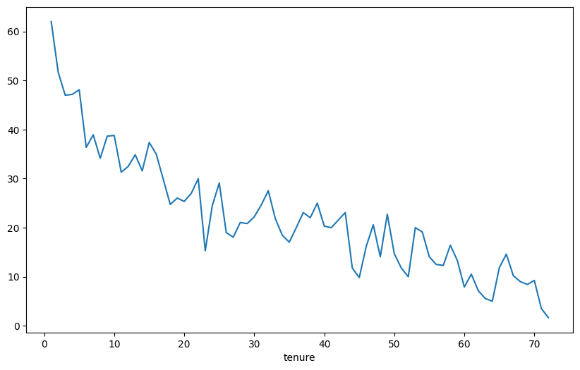

```python
churn_rate.T['customerID'].plot()
```

### Broader Cohort Groups

**TASK: Based on the tenure column values, create a new column called Tenure Cohort that creates 4 separate categories:**

- '0-12 Months'
- '12-24 Months'
- '24-48 Months'
- 'Over 48 Months'

```python
df['tenure'] <=12
```

```
0        True
1       False
2        True
3       False
4        True
        ...
7027    False
7028    False
7029     True
7030     True
7031    False
Name: tenure, Length: 7032, dtype: bool
```

```python
def cohort(tenure):
    if tenure<12:
        return '0-12 Months'
    elif tenure<25:
        return '12-24 Months'
    elif tenure <49:
        return '24-48 Months'
    else:
        return 'Over 48 Months'
```

```python
df['Tenure Cohort'] = df['tenure'].apply(cohort)
```

```python
df[['Tenure Cohort','tenure']]
```

|  | Tenure Cohort | tenure |
| --- | --- | --- |
| 0 | 0-12 Months | 1 |
| 1 | 24-48 Months | 34 |
| 2 | 0-12 Months | 2 |
| 3 | 24-48 Months | 45 |
| 4 | 0-12 Months | 2 |
| ... | ... | ... |
| 7027 | 12-24 Months | 24 |
| 7028 | Over 48 Months | 72 |
| 7029 | 0-12 Months | 11 |
| 7030 | 0-12 Months | 4 |
| 7031 | Over 48 Months | 66 |

7032 rows × 2 columns

**TASK: Create a scatterplot of Total Charges versus Monthly Charts,colored by Tenure Cohort defined in the previous task.**

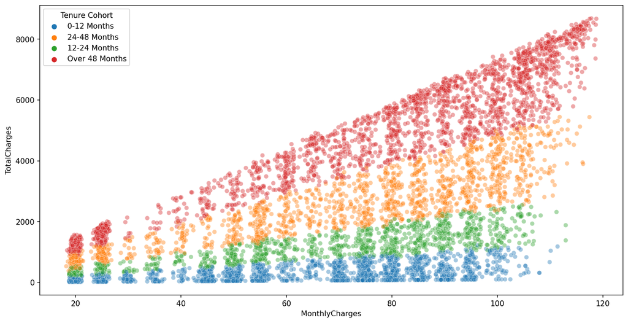

```python
plt.figure(figsize=(14,7),dpi=150)
sns.scatterplot(data=df,x="MonthlyCharges",y='TotalCharges',hue='Tenure Cohort',alpha=0.4)
```

**TASK: Create a count plot showing the churn count per cohort.**

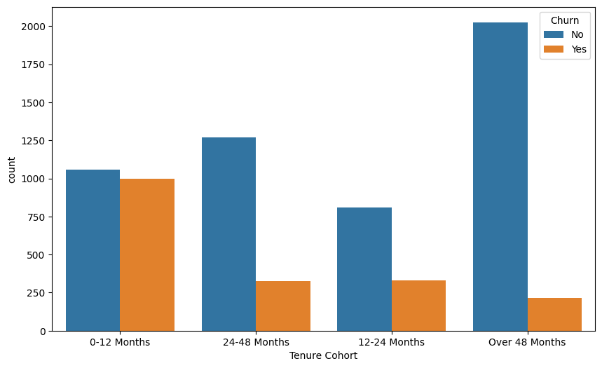

```python
sns.countplot(data=df,hue='Churn',x='Tenure Cohort')
```

**TASK: Create a grid of Count Plots showing counts per Tenure Cohort, separated out by contract type and colored by the Churn hue.**

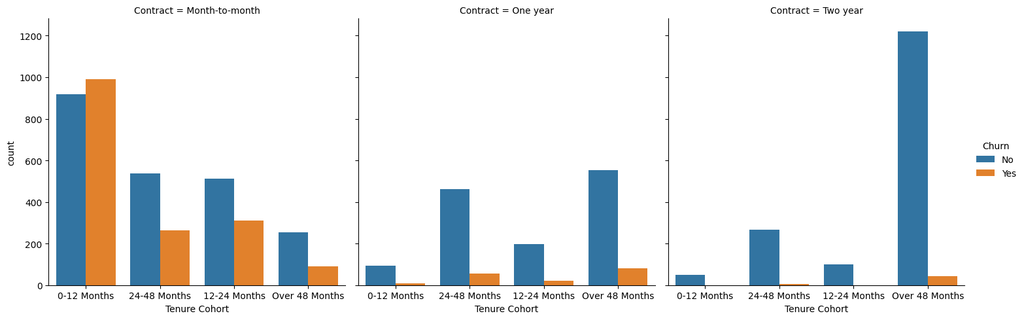

```python
sns.catplot(data=df,x='Tenure Cohort',hue='Churn',kind='count',col='Contract')
```

# Part 4: Predictive Modeling

**Let's explore 4 different tree based methods: A Single Decision Tree, Random Forest, AdaBoost, Gradient Boosting. Feel free to add any other supervised learning models to your comparisons!**

## Single Decision Tree

**TASK : Separate out the data into X features and Y label. Create dummy variables where necessary and note which features are not useful and should be dropped.**

```python
X = df.drop(['Churn','customerID'],axis=1)
```

```python
X = pd.get_dummies(X,drop_first=True)
```

```python
y= df['Churn']
```

**TASK: Perform a train test split, holding out 10% of the data for testing. We'll use a random_state of 101 in the solutions notebook/video.**

```python
from sklearn.model_selection import train_test_split
```

```python
X_train, X_test, y_train, y_test = train_test_split(X, y, test_size=0.1, random_state=101)
```

**TASK: Decision Tree Perfomance. Complete the following tasks:**

1. Train a single decision tree model (feel free to grid search for optimal hyperparameters).
2. Evaluate performance metrics from decision tree, including classification report and plotting a confusion matrix.
3. Calculate feature importances from the decision tree.
4. OPTIONAL: Plot your tree, note, the tree could be huge depending on your pruning, so it may crash your notebook if you display it with plot_tree.

```python
from sklearn.tree import  DecisionTreeClassifier
```

```python
dt = DecisionTreeClassifier(max_depth=6)
```

```python
dt.fit(X_train,y_train)
```

```
DecisionTreeClassifier(max_depth=6)
```

```python
from sklearn.metrics import classification_report, plot_confusion_matrix,accuracy_score
```

```python
prediction = dt.predict(X_test)
```

```python
print(classification_report(y_test,prediction))
```

```
              precision    recall  f1-score   support

          No       0.87      0.89      0.88       557
         Yes       0.55      0.49      0.52       147

    accuracy                           0.81       704
   macro avg       0.71      0.69      0.70       704
weighted avg       0.80      0.81      0.80       704
```

```
c:\Users\Ravi Nadageri\Python_3_10\lib\site-packages\sklearn\utils\deprecation.py:87: FutureWarning: Function plot_confusion_matrix is deprecated; Function `plot_confusion_matrix` is deprecated in 1.0 and will be removed in 1.2. Use one of the class methods: ConfusionMatrixDisplay.from_predictions o…
  warnings.warn(msg, category=FutureWarning)
```

```
<sklearn.metrics._plot.confusion_matrix.ConfusionMatrixDisplay at 0x205805f05b0>
```

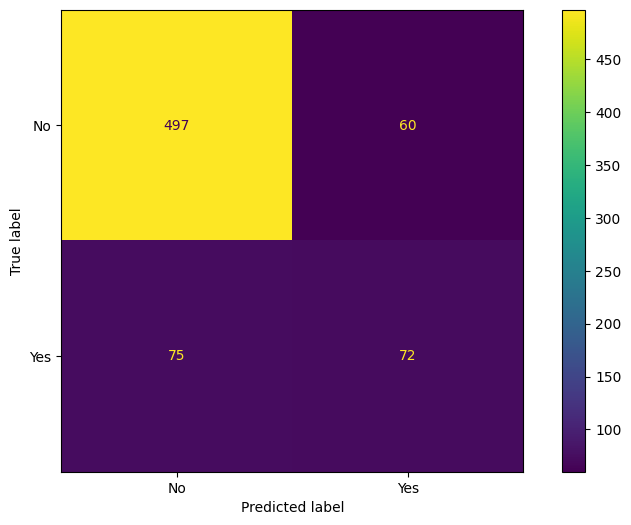

```python
plot_confusion_matrix(dt,X_test,y_test)
```

```python
imp_feature = pd.DataFrame(data=dt.feature_importances_,index=X.columns,columns=['feature_Importance']).sort_values('feature_Importance')
```

```python
imp_feature = imp_feature[imp_feature['feature_Importance']>0]
imp_feature
```

|  | feature_Importance |
| --- | --- |
| PhoneService_Yes | 0.000890 |
| gender_Male | 0.001237 |
| OnlineBackup_Yes | 0.005341 |
| MultipleLines_No phone service | 0.006962 |
| TechSupport_Yes | 0.007868 |
| OnlineSecurity_Yes | 0.008376 |
| Contract_One year | 0.010021 |
| SeniorCitizen | 0.010825 |
| MultipleLines_Yes | 0.012432 |
| OnlineBackup_No internet service | 0.026290 |
| Contract_Two year | 0.027065 |
| PaymentMethod_Electronic check | 0.034436 |
| MonthlyCharges | 0.042293 |
| TotalCharges | 0.067990 |
| InternetService_Fiber optic | 0.314060 |
| tenure | 0.423914 |

```
(array([ 0,  1,  2,  3,  4,  5,  6,  7,  8,  9, 10, 11, 12, 13, 14, 15]),
 [Text(0, 0, 'PhoneService_Yes'),
```

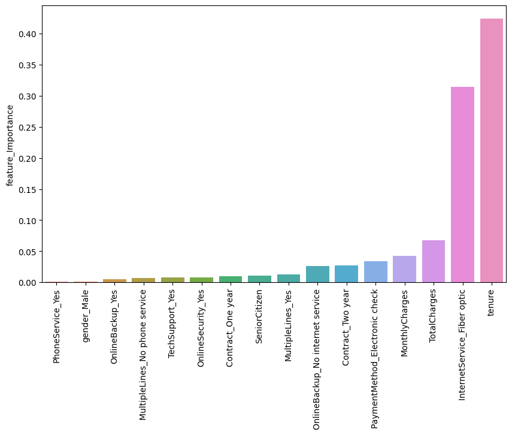

```python
sns.barplot(data=imp_feature,x=imp_feature.index,y=imp_feature['feature_Importance'])
plt.xticks(rotation=90)
```

```python
from sklearn.tree import plot_tree
```

```
[Text(0.48522727272727273, 0.9285714285714286, 'X[1] <= 17.5\ngini = 0.396\nsamples = 6328\nvalue = [4606, 1722]'),
```

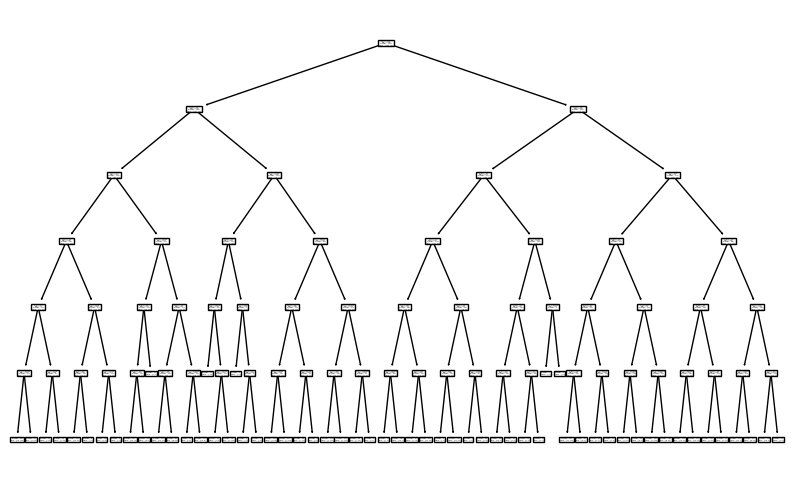

```python
plot_tree(dt)
```

## Random Forest

**TASK: Create a Random Forest model and create a classification report and confusion matrix from its predicted results on the test set.**

```python
from sklearn.ensemble import RandomForestClassifier
```

```python
rfc = RandomForestClassifier(max_depth=6)
```

```python
rfc.fit(X_train,y_train)
```

```
RandomForestClassifier(max_depth=6)
```

```python
pred = rfc.predict(X_test)
```

```python
print(classification_report(y_test,pred))
```

```
              precision    recall  f1-score   support

          No       0.86      0.93      0.90       557
         Yes       0.63      0.45      0.52       147

    accuracy                           0.83       704
   macro avg       0.75      0.69      0.71       704
weighted avg       0.82      0.83      0.82       704
```

```
c:\Users\Ravi Nadageri\Python_3_10\lib\site-packages\sklearn\utils\deprecation.py:87: FutureWarning: Function plot_confusion_matrix is deprecated; Function `plot_confusion_matrix` is deprecated in 1.0 and will be removed in 1.2. Use one of the class methods: ConfusionMatrixDisplay.from_predictions o…
  warnings.warn(msg, category=FutureWarning)
```

```
<sklearn.metrics._plot.confusion_matrix.ConfusionMatrixDisplay at 0x2058205a5f0>
```

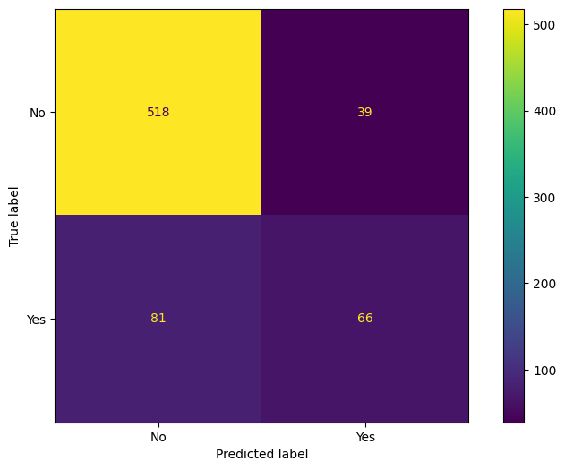

```python
plot_confusion_matrix(rfc,X_test,y_test)
```

## Boosted Trees

**TASK: Use AdaBoost or Gradient Boosting to create a model and report back the classification report and plot a confusion matrix for its predicted results**

```python
from sklearn.ensemble import GradientBoostingClassifier, AdaBoostClassifier
```

```python
ada_model = AdaBoostClassifier()
```

```python
gb_model = GradientBoostingClassifier()
```

```python
ada_model.fit(X_train,y_train)
```

```
AdaBoostClassifier()
```

```python
gb_model.fit(X_train,y_train)
```

```
GradientBoostingClassifier()
```

```python
ada_pred = ada_model.predict(X_test)
gb_pred = gb_model.predict(X_test)
```

```python
print(classification_report(y_test,ada_pred))
```

```
              precision    recall  f1-score   support

          No       0.88      0.90      0.89       557
         Yes       0.60      0.54      0.57       147

    accuracy                           0.83       704
   macro avg       0.74      0.72      0.73       704
weighted avg       0.82      0.83      0.83       704
```

```python
print(classification_report(y_test,gb_pred))
```

```
              precision    recall  f1-score   support

          No       0.87      0.90      0.89       557
         Yes       0.58      0.51      0.54       147

    accuracy                           0.82       704
   macro avg       0.73      0.71      0.71       704
weighted avg       0.81      0.82      0.82       704
```

```
c:\Users\Ravi Nadageri\Python_3_10\lib\site-packages\sklearn\utils\deprecation.py:87: FutureWarning: Function plot_confusion_matrix is deprecated; Function `plot_confusion_matrix` is deprecated in 1.0 and will be removed in 1.2. Use one of the class methods: ConfusionMatrixDisplay.from_predictions o…
  warnings.warn(msg, category=FutureWarning)
```

```
<sklearn.metrics._plot.confusion_matrix.ConfusionMatrixDisplay at 0x2058205a320>
```

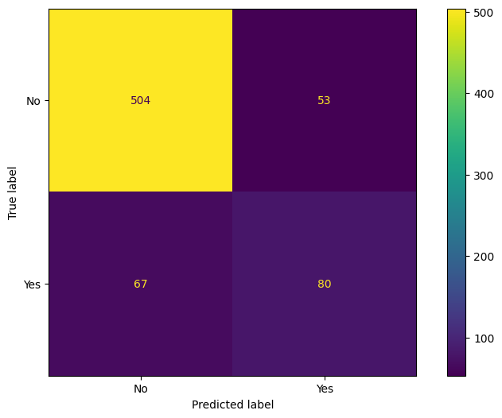

```python
plot_confusion_matrix(ada_model,X_test,y_test)
```

```
c:\Users\Ravi Nadageri\Python_3_10\lib\site-packages\sklearn\utils\deprecation.py:87: FutureWarning: Function plot_confusion_matrix is deprecated; Function `plot_confusion_matrix` is deprecated in 1.0 and will be removed in 1.2. Use one of the class methods: ConfusionMatrixDisplay.from_predictions o…
  warnings.warn(msg, category=FutureWarning)
```

```
<sklearn.metrics._plot.confusion_matrix.ConfusionMatrixDisplay at 0x205851cada0>
```

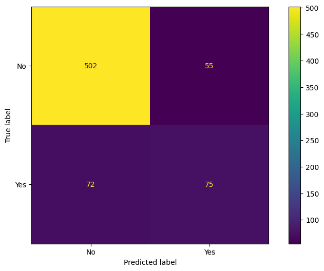

```python
plot_confusion_matrix(gb_model,X_test,y_test)
```

**TASK: Analyze your results, which model performed best for you?**

```python
# With base models, we got best performance from an AdaBoostClassifier, but note, we didn't do any gridsearching AND most models performed about the same on the data set.
```